# 200406_Titanic_3번째노트북_필사1회

### 5.2 Family size

우리는 가족규모가 클수록 구조하기 힘들다고 상상할수 있겠죠? 사람이 이렇게 많은데 서로 챙기려는 가족들보다는 아마 개별 가족들의 생존력이 더 높을 것입니다. 그래서 SIbSP, Parch에서 Family size 즉 Fize라는 컬럼을 뽑아내려고 합니다. Sib과 Parch에 본인을 더해야하니 +1을 해준값으로 Fize를 설정합니다

```python
dataset['Fsize'] = dataset['SibSp'] + dataset["Parch"] + 1
```

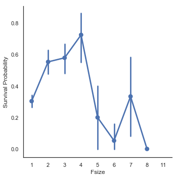

```python
g = sns.factorplot(x='Fsize',y='Survived',data=dataset)
g = g.set_ylabels('Survival Probability')
```

그리고 Fsize를 4개의 큰카테고리로 나눕니다. 모델링이 좀더 잘 되게 하기위해 생존률의 범주를 좀 넓게 잡아주려고 합니다. 1명/2명/3-4명/5명이상으로 나누겠습니다. map 메소드로 각각 4개의 컬럼이 추가됩니다. 해당하면 1, 아니면 0인 원핫인코딩이지만 범위를 직접 코딩한다고 보면 되겠네요.

```python
dataset['Single'] = dataset['Fsize'].map(lambda s: 1 if s == 1 else 0)
dataset['SmallF'] = dataset['Fsize'].map(lambda s: 1 if s == 2 else 0)
dataset['MedF'] = dataset['Fsize'].map(lambda s: 1 if 3 <= s <= 4 else 0)
dataset['LargeF'] = dataset['Fsize'].map(lambda s: 1 if s >= 5 else 0)
```

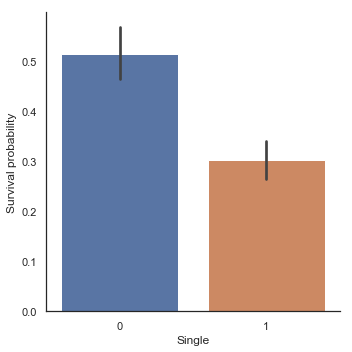

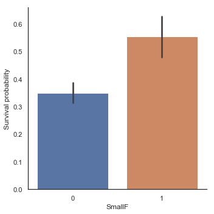

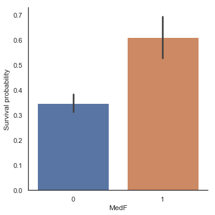

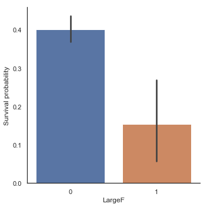

```python
g = sns.factorplot(x='Single', y='Survived', data=dataset, kind='bar')
g = g.set_ylabels('Survival probability')
g = sns.factorplot(x='SmallF', y='Survived', data=dataset, kind='bar')
g = g.set_ylabels('Survival probability')
g = sns.factorplot(x='MedF', y='Survived', data=dataset, kind='bar')
g = g.set_ylabels('Survival probability')
g = sns.factorplot(x='LargeF', y='Survived', data=dataset, kind='bar')
g = g.set_ylabels('Survival probability')
```

```python
dataset = pd.get_dummies(dataset, columns=['Title'])
dataset = pd.get_dummies(dataset, columns=['Embarked'], prefix='Em')  #--> Em?
```

```python
dataset.head(2)
```

[output not shown]

```python
dataset['Cabin'].head(2)
```

[output not shown]

```python
dataset['Cabin'].describe()
```

[output not shown]

```python
dataset['Cabin'].isnull().sum()
```

[output not shown]

```python
dataset['Cabin'][dataset['Cabin'].notnull()].head()
```

[output not shown]

```python
dataset['Cabin'] = pd.Series(i[0] if not pd.isnull(i) else 'X' for i in dataset['Cabin'])
```

```python
g = sns.countplot(dataset['Cabin'], order=['A','B','C','D','E','F','G','T','X'])
```

[output not shown]

```python
g = sns.factorplot(x='Cabin',y='Survived', data=dataset, kind='bar', order=['A','B','C','D','E','F','G','T','X'])
g = g.set_ylabels('Survival Prob.')
```

[output not shown]

```python
dataset = pd.get_dummies(dataset, columns = ["Cabin"], prefix='Cabin')
```

```python
dataset['Ticket'].head(2)
```

[output not shown]

```python
Ticket = []
for i in list(dataset.Ticket):
    if not i.isdigit():
        Ticket.append(i.replace(".","").replace("/","").strip().split(' ')[0])
    else:
        Ticket.append('X')

dataset['Ticket'] = Ticket
dataset['Ticket'].head()
```

[output not shown]

```python
dataset = pd.get_dummies(dataset, columns=['Ticket'],prefix="T")
```

```python
dataset['Pclass'] = dataset['Pclass'].astype('category')
dataset = pd.get_dummies(dataset, columns=['Pclass'], prefix='Pc')
```

```python
dataset.drop(labels=["PassengerId"],axis=1, inplace=True)
```

```python
dataset.head()
```

[output not shown]

# Modeling

```python
train = dataset[:train_len]
test = dataset[train_len:]
test.drop(labels=['Survived'],axis=1,inplace=True)
```

```python
train['Survived'] = train['Survived'].astype(int)
Y_train = train['Survived']
X_train = train.drop(labels=['Survived'],axis=1)
```

simple modeling

```python
X_train.dtypes
```

[output not shown]

```python
kfold = StratifiedKFold(n_splits=10)
```

```python
random_state=2
classifiers=[]
classifiers.append(SVC(random_state=random_state))
classifiers.append(DecisionTreeClassifier(random_state=random_state))
classifiers.append(AdaBoostClassifier(DecisionTreeClassifier(random_state=random_state), random_state=random_state, learning_rate=0.1))
classifiers.append(RandomForestClassifier(random_state=random_state))
classifiers.append(ExtraTreesClassifier(random_state=random_state))
classifiers.append(GradientBoostingClassifier(random_state=random_state))
classifiers.append(MLPClassifier(random_state=random_state))
classifiers.append(KNeighborsClassifier())
classifiers.append(LogisticRegression(random_state=random_state))
classifiers.append(LinearDiscriminantAnalysis())

cv_results=[]
for classifier in classifiers:
    cv_results.append(cross_val_score(classifier, X_train, y=Y_train, scoring='accuracy', cv=kfold, n_jobs=4))

cv_means=[]
cv_std=[]
for cv_result in cv_results:
    cv_means.append(cv_result.mean())
    cv_std.append(cv_result.std())

cv_res = pd.DataFrame({'CrossValMeans':cv_means,'CrossValerrors':cv_std,'Algorithm':['SVC','DecisionTree','AdaBoost','RandomForest','ExtraTrees','GradientBoosting','MultipleLayerPerceptron','KNeighbors','LogisticRegression','LinearDiscriminantAnalysis']})

g = sns.barplot('CrossValMeans','Algorithm',data=cv_res, palette='Set3',orient='h',**{'xerr':cv_std})
g.set_xlabel("Mean Accuracy")
g = g.set_title('Cross validation scores')
```

[output not shown]

```python
random_state = 2
classifiers = []
classifiers.append(SVC(random_state=random_state))
classifiers.append(DecisionTreeClassifier(random_state=random_state))
classifiers.append(AdaBoostClassifier(DecisionTreeClassifier(random_state=random_state),random_state=random_state,learning_rate=0.1))
classifiers.append(RandomForestClassifier(random_state=random_state))
classifiers.append(ExtraTreesClassifier(random_state=random_state))
classifiers.append(GradientBoostingClassifier(random_state=random_state))
classifiers.append(MLPClassifier(random_state=random_state))
classifiers.append(KNeighborsClassifier())
classifiers.append(LogisticRegression(random_state = random_state))
classifiers.append(LinearDiscriminantAnalysis())

cv_results = []
for classifier in classifiers :
    cv_results.append(cross_val_score(classifier, X_train, y = Y_train, scoring = "accuracy", cv = kfold, n_jobs=4))

cv_means = []
cv_std = []
for cv_result in cv_results:
    cv_means.append(cv_result.mean())
    cv_std.append(cv_result.std())

cv_res = pd.DataFrame({"CrossValMeans":cv_means,"CrossValerrors": cv_std,"Algorithm":["SVC","DecisionTree","AdaBoost",
"RandomForest","ExtraTrees","GradientBoosting","MultipleLayerPerceptron","KNeighboors","LogisticRegression","LinearDiscriminantAnalysis"]})

g = sns.barplot("CrossValMeans","Algorithm",data = cv_res, palette="Set3",orient = "h",**{'xerr':cv_std})
g.set_xlabel("Mean Accuracy")
g = g.set_title("Cross validation scores")
```

[output not shown]

Hyperparameter tuning for best models

```python
DTC = DecisionTreeClassifier()

adaDTC = AdaBoostClassifier(DTC, random_state=7)

ada_param_grid = {'base_estimator__criterion' : ['gini','entropy'],
                 'base_estimator__splitter': ['best', 'random'],
                 'algorithm' : ['SAMME','SAMME_R'],
                 'n_estimators':[1,2],
                 'learning_rate': [0.0001,0.001,0.01,0.1,0.2,0.3,1.5]}

gsadaDTC = GridSearchCV(adaDTC, param_grid = ada_param_grid, cv=kfold, scoring='accuracy', n_jobs=-1, verbose=1)

gsadaDTC.fit(X_train, Y_train)
ada_best = gsadaDTC.best_estimator_
```

```python
gsadaDTC.best_score_
```

[output not shown]

```python
ExtC = ExtraTreesClassifier()

ex_param_grid = {'max_depth': [None],
                 'max_features':[1,3,10],
                 'min_samples_split':[2,3,10],
                 'min_samples_leaf':[1,3,10],
                 'bootstrap':[False],
                 'n_estimators':[100,300],
                 'criterion':['gini']}

gsExtC = GridSearchCV(ExtC, param_grid=ex_param_grid,cv=kfold,
                      scoring='accuracy',n_jobs=-1,verbose=1)

gsExtC.fit(X_train, Y_train)

ExtC_best = gsExtC.best_estimator_
gsExtC.best_score_
```

[output not shown]

```python
RFC = RandomForestClassifier()

rf_param_grid = {'max_depth': [None],
                 'max_features':[1,3,10],
                 'min_samples_split':[2,3,10],
                 'min_samples_leaf':[1,3,10],
                 'bootstrap':[False],
                 'n_estimators':[100,300],
                 'criterion':['gini']
                }

gsRFC = GridSearchCV(RFC, param_grid=rf_param_grid, cv=kfold, scoring='accuracy', n_jobs=-1, verbose=1)

gsRFC.fit(X_train, Y_train)

RFC_best = gsRFC.best_estimator_

gsRFC.best_score_
```

[output not shown]

```python
GBC = GradientBoostingClassifier()
gb_param_grid = {'loss':['deviance'],
                 'n_estimators':[100,200,300],
                 'learning_rate':[0.1,0.05,0.01],
                 'max_depth':[4,8],
                 'min_samples_leaf':[100,150],
                 'max_features':[0.3,0.1],
                }
gsGBC = GridSearchCV(GBC, param_grid=gb_param_grid, cv=kfold, scoring='accuracy', n_jobs=-1, verbose=1)

gsGBC.fit(X_train, Y_train)

GBC_best = gsGBC.best_estimator_
gsGBC.best_score_
```

[output not shown]

```python
SVMC = SVC(probability=True)
svc_param_grid = {'kernel':['rbf'],
                  'gamma':[0.001,0.01,0.1,1],
                  'C':[1,10,50,100,200,300,1000]}

gsSVMC = GridSearchCV(SVMC, param_grid=svc_param_grid, scoring='accuracy', n_jobs=-1, verbose=1)

gsSVMC.fit(X_train, Y_train)

SVMC_best= gsSVMC.best_estimator_

gsSVMC.best_score_
```

[output not shown]

### Plot learning curves

```python
def plot_learning_curve(estimator, title, X, y, ylim=None, cv=None,
                        n_jobs=-1, train_sizes=np.linspace(.1,1.0,5)):
    plt.figure()
    plt.title(title)
    if ylim is not None:
        plt.ylim(*ylim)
    plt.xlabel("Training examples")
    plt.ylabel('Score')
    train_sizes, train_scores, test_scores = learning_curve(
        estimator, X, y, cv=cv, n_jobs=n_jobs, train_sizes=train_sizes)
    train_scores_mean = np.mean(train_scores, axis=1)
    train_scores_std = np.std(train_scores, axis=1)
    test_scores_mean = np.mean(test_scores, axis=1)
    test_scores_std = np.std(test_scores, axis=1)
    plt.grid()

    plt.fill_between(train_sizes, train_scores_mean - train_scores_std,
                    train_scores_mean + train_scores_std, alpha=0.1, color='r')
    plt.fill_between(train_sizes, test_scores_mean - test_scores_std,
                    test_scores_mean + test_scores_std, alpha=0.1, color='g')
    plt.plot(train_sizes, train_scores_mean, 'o-', color='r', label='Training Score')
    plt.plot(train_sizes, test_scores_mean, 'o-', color='g', label='Cross-validation score')

    plt.legend(loc='best')
    return plt

g = plot_learning_curve(gsRFC.best_estimator_, "RF mearning curves",X_train,Y_train,cv=kfold)
g = plot_learning_curve(gsExtC.best_estimator_,"ExtraTrees learning curves",X_train,Y_train,cv=kfold)
g = plot_learning_curve(gsSVMC.best_estimator_,'SVC learning curves',X_train,Y_train,cv=kfold)
g = plot_learning_curve(gsadaDTC.best_estimator_,'AdaBoost learning curves',X_train,Y_train,cv=kfold)
g = plot_learning_curve(gsGBC.best_estimator_,'GradientBoosting learning curves',X_train,Y_train,cv=kfold)
```

[output not shown]

```python
nrows = ncols = 2
fig,axes = plt.subplots(nrows=nrows, ncols=ncols, sharex='all',figsize=(15,15))

names_classifiers = [("AdaBoosting",ada_best),('ExtraTrees',ExtC_best),
                     ('RandomForest',RFC_best),("GradientBoosting",GBC_best)]

nclassifier = 0
for row in range(nrows):
    for col in range(ncols):
        name = names_classifiers[nclassifier][0]
        classifier = names_classifiers[nclassifier][1]
        indices = np.argsort(classifier.feature_importances_)[::-1][:40]
        g = sns.barplot(y=X_train.columns[indices][:40],x=classifier.feature_importances_[indices][:40], orient='h',ax=axes[row][col])
        g.set_xlabel('Relative importance',fontsize=12)
        g.set_ylabel('Features',fontsize=12)
        g.tick_params(labelsize=9)
        g.set_title(name + 'feature importance')
        nclassifier += 1
```

[output not shown]

```python
test_Survived_RFC = pd.Series(RFC_best.predict(test), name='RFC')
test_Survived_ExtC = pd.Series(ExtC_best.predict(test), name='ExtC')
test_Survived_SVMC = pd.Series(SVMC_best.predict(test), name='SVC')
test_Survived_AdaC = pd.Series(ada_best.predict(test), name='Ada')
test_Survived_GBC = pd.Series(GBC_best.predict(test), name='GBC')


ensemble_results = pd.concat([test_Survived_RFC, test_Survived_ExtC, test_Survived_AdaC, test_Survived_GBC,test_Survived_SVMC],axis=1)

g = sns.heatmap(ensemble_results.corr(),annot=True,cmap=sns.cubehelix_palette(8))
```

[output not shown]

Ensemble modeling

```python
votingC = VotingClassifier(estimators=[('rfc',RFC_best),('extc',ExtC_best),
                                      ('svc',SVMC_best),('adac',ada_best),
                                      ('gbc',GBC_best)],
                           voting='soft',n_jobs=-1)

votingC = votingC.fit(X_train, Y_train)
```

```python
test_Survived = pd.Series(votingC.predict(test),name='Survived')
results= pd.concat([IDtest,test_Survived],axis=1)
results.to_csv('ensemble_python_voting.csv',index=False)
```